# Лабораторная работа № 1

Berezovik Ekaterina

28 сентября 2017 г

**Исходные данные**

Экспоненциальное распределение определяется следующей функцией распределения:

$F(x)=1-e^{-λ⋅x}$

**Задание 1**

1. Генерация 200 случайных значений из стандартного экспоненциального распределения. Нахождение среднего и стандартного отклонений из данных этого вектора.

```r
        exp.1=rexp(n=200)

    #Среднее отклонение
        mean(exp.1)
```

```
## [1] 0.9445274
```

```r
    #Стандартное отклонение
        sd(exp.1)
```

```
## [1] 0.9898062
```

2. Повторение п.1, используя следующие значения параметра λ: 0.1, 0.5, 5, 10

```r
        exp.0.1=rexp(n=200,rate=0.1)
        mean(exp.0.1)
```

```
## [1] 9.771909
```

```r
        sd(exp.0.1)
```

```
## [1] 10.79258
```

```r
        exp.0.5=rexp(n=200,rate=0.5)
        mean(exp.0.5)
```

```
## [1] 2.153911
```

```r
        sd(exp.0.5)
```

```
## [1] 2.129885
```

```r
        exp.5=rexp(n=200,rate=5)
        mean(exp.5)
```

```
## [1] 0.1719083
```

```r
        sd(exp.5)
```

```
## [1] 0.1609323
```

```r
        exp.10=rexp(n=200,rate=10)
        mean(exp.10)
```

```
## [1] 0.08949366
```

```r
        sd(exp.10)
```

```
## [1] 0.08509763
```

```
  Функция plot() общая функция для визуализации данных. Функция hist() принимает данные и раскладывает их по корзинам. Чтобы использовать эти функции нужно для начала передать им данные, которые хотим визуализировать.
```

3. Использование функции hist() для построения гистограммы полученного ранее стандартного распределения.

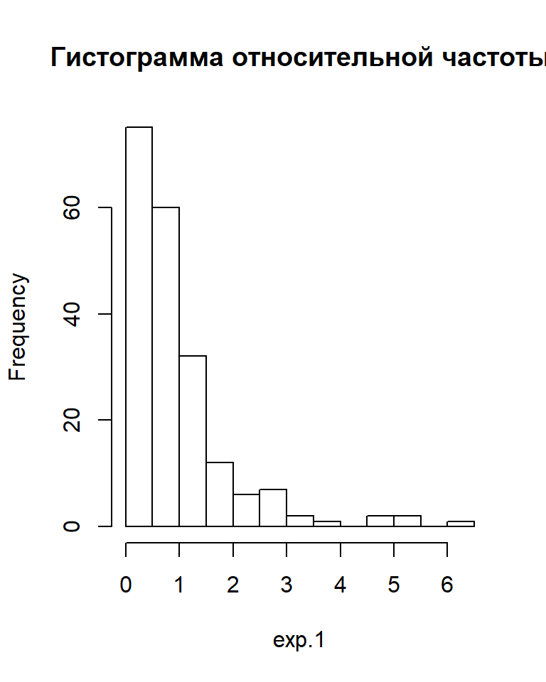

```r
        hist(exp.1, main = "Гистограмма относительной частоты")
```

4. Использование функции plot() с тем же самым вектором для построения графика значений в порядке следования.

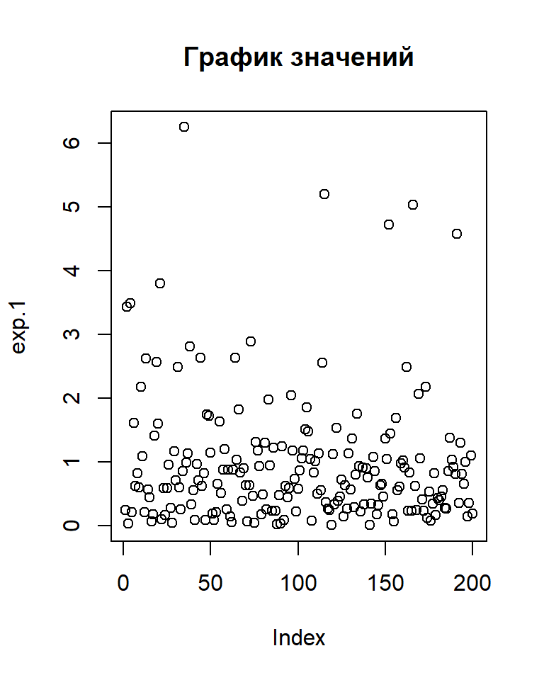

```r
        plot(exp.1, main = "График значений")
```

5. Использование функции plot() с любыми двумя полученными ранее векторами, чтобы получить диаграмму рассеяния (scatterplot) этих векторов относительно друг друга.

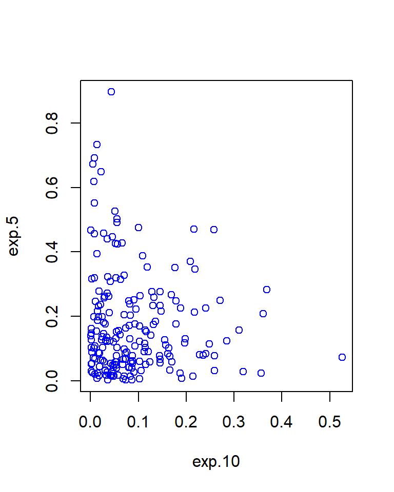

```r
         plot(exp.10, exp.5, col="blue", type="p")
```

6. Сравнение свойств всех векторов.

```r
     lambda<-c(1, 0.1, 0.5, 5, 10)
     exp.means<-c(mean(exp.1), mean(exp.0.1), mean(exp.0.5), mean(exp.5), mean(exp.10))
     exp.sds<-c(sd(exp.1), sd(exp.0.1), sd(exp.0.5), sd(exp.5), sd(exp.10))
```

- Вектор с пятью средними относительно каждого из пяти векторов с различными значениями λ.

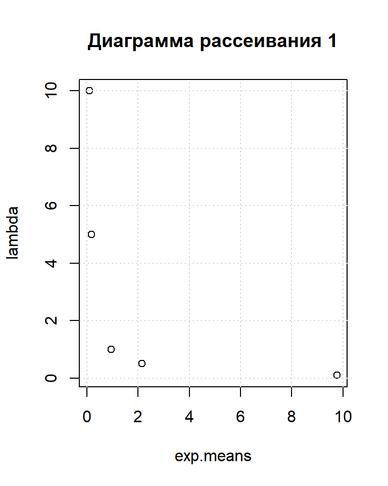

```r
     plot(exp.means, lambda, type='p', col='black')
     grid()
     title("Диаграмма рассеивания 1")
```

*Пояснение получившегося графика*

Чем больше значение λ, тем меньше среднее отклонение

- Вектор с пятью стандартными отклонениями относительно каждого из пяти векторов с различными значениями λ.

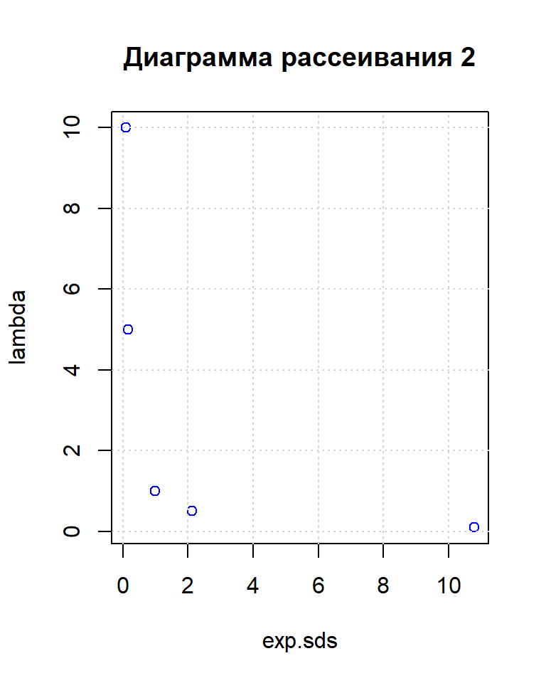

```r
     plot( exp.sds,lambda, type='p', col='blue')
     grid()
     title("Диаграмма рассеивания 2")
```

*Пояснение получившегося графика*

Чем больше значение λ, тем меньше стандартное отклонение

- Вектор с пятью средними относительно вектора с пятью стандартными отклонениями.

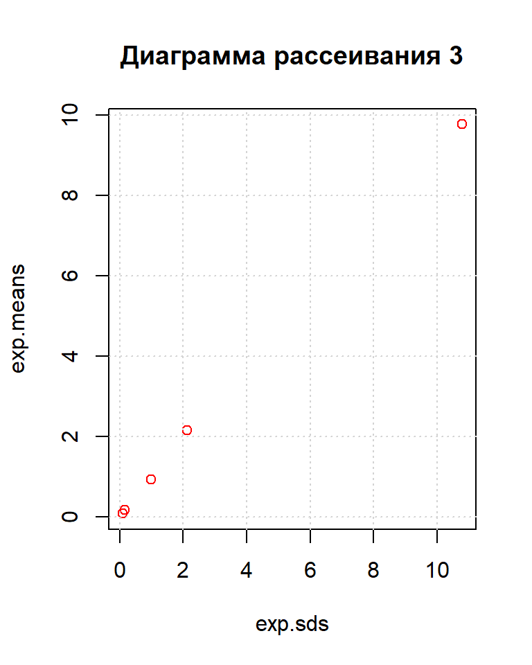

```r
    plot( exp.sds, exp.means, type='p', col='red')
    grid()
    title("Диаграмма рассеивания 3")
```

*Пояснение получившегося графика*

Среднее отклонение и стандартное отклонение почти идентичны

**Задание 2**

- Генерация 1100000 (1 млн. 100 тысяч) чисел из стандартного экспоненциального распределения. Получение среднего и стандартного отклонений.

```r
   huge.exp.1=rexp(n=1100000,rate=1)
   mean(huge.exp.1)
```

```
## [1] 0.9996356
```

```r
   sd(huge.exp.1)
```

```
## [1] 0.9992039
```

- Получение гистограммы п.1.

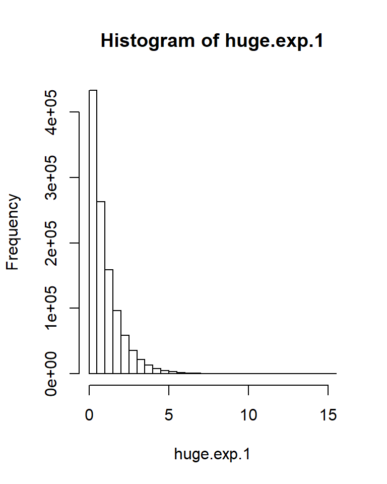

```r
 huge.exp.1=rexp(n=1100000,rate=1)
 hist(huge.exp.1)
```

*Соответствует ли функции $1-e^{-x}$? Должна ли?*

`## [1] 0.3678691`

- Получение матрицы из п.1, содержащую 1100 строк и 1000 колонок. Построение гистограмму, использовав полученную матрицу.

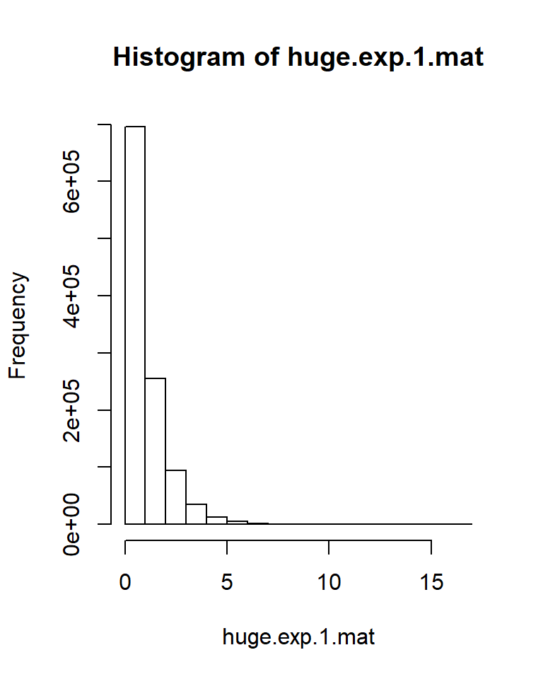

```r
  huge.exp.1.mat <- matrix(data = rexp(n=1100000,rate=1), nrow = 1100, ncol = 1000)
  hist(huge.exp.1.mat)
```

*Что можно сказать о полученных данных?*  
Полученная гистограмма соответствует экспоненциальному распределению.

- Рассчитайте среднее 137-й колонки из huge.exp.1.mat.

```r
    mean(huge.exp.1.mat[,137])
```

```
## [1] 1.011137
```

- Найдите среднее всей 1000 колонок и сохраните их в вектор. Отобразите диаграмму средних зннчений колонок.

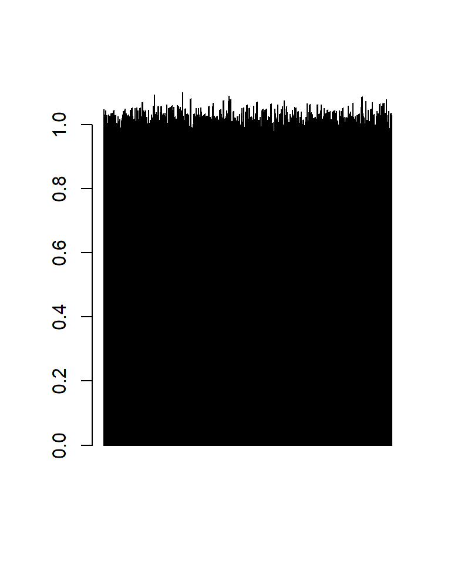

```r
  huge.exp.1.vec <- colMeans(huge.exp.1.mat)
  barplot(huge.exp.1.vec)
```

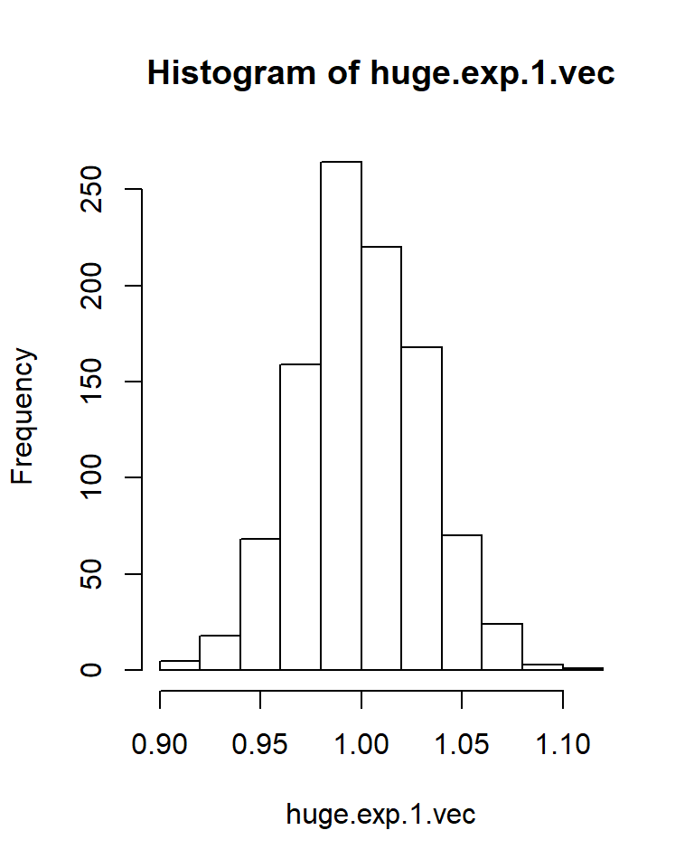

```r
  hist(huge.exp.1.vec)
```

*Объясните почему форма диаграммы отличается от виденных ранее.* Данная диаграмма отличается от всех предыдущих, потому что построен по среднем значениям.

- Рассчитайте квадрат каждого значения из huge.exp.1 и найдите среднее и стандартное отклонение полученного вектора квадратов.

```r
  huge.exp.1.sq=(huge.exp.1)^2
  mean(huge.exp.1.sq)
```

```
## [1] 2.008487
```

```r
  sd(huge.exp.1.sq)
```

```
## [1] 4.4983
```

*Объясните отличие от соответствующих показателей вектора huge.exp.1. Вам может помочь формула, по которой R рассчитывает стандартное отклонение: sqrt(sum{(x - mean(x))^2} / {n - 1})*  
Среднее и стандартное отклонения увеличиваются с увеличением значений вектора.

Стандартное отклонение растет в 2 раза быстрее из-за квадрата в формуле его вычисления.